# OCNMS exploratory plots

Ole Shelton

November 30, 2015

This is a basic file for processing and providing basic plots for the 2015 Olympic Coast National Marine Sanctuary Dive Surveys.

## The important data.frames and lists for 2015 data are these:

- “dat.quad” has all of the pecent cover data associated with quadrat counts
- “dat.quad.count” has all of the count data of mobile and countable inverts from the quadrat surveys
- “dat.trans.alge” has all the transect observations for algae an
- “dat.trans.mammal.bird” has all the mammal and bird observations
- “dat.trans.fish” has all of the transect observations for fish species.
- “dat.trans.invert” has all of the transect observations for invertebrates. I made this into a list that has multiple entries for species folk are likely interested in

```r
names(dat.trans.invert)
```

```
##  [1] "All.invert" "Urchin"     "Cucumber"   "Sea.star"   "Crab"
##  [6] "Chiton"     "Limpet"     "Gastropod"  "Bivalve"    "Nudi"
```

All surveys were conducted on these dates:

```
## [1] "8/3/15" "8/4/15" "8/5/15" "8/6/15" "8/7/15"
```

Here is a map showing the approximate locations of the sites

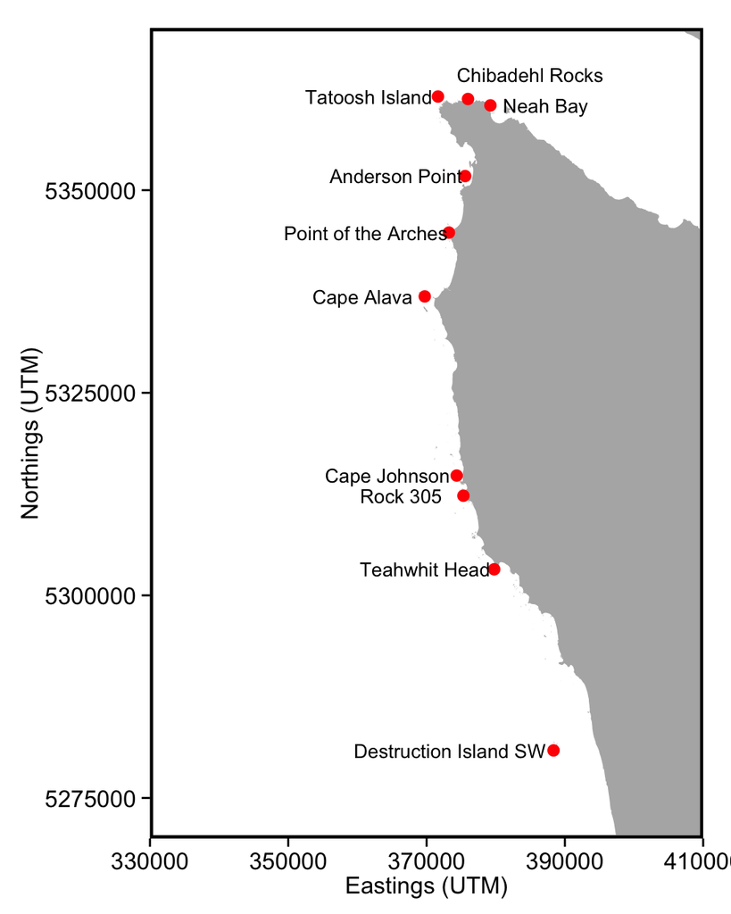

\newpage

## Methods

Four divers conducted dive surveys at each site (two teams of two). Each diver pair surveyed two 30m long transects. All dives in 2015 were conducted at about 6-8m depth.

I’ve focused on summarizing the species observed in at each site (for the quadrats, invertebrate transects, and fish transects)

### Sessile creatures (and some benthic categories)

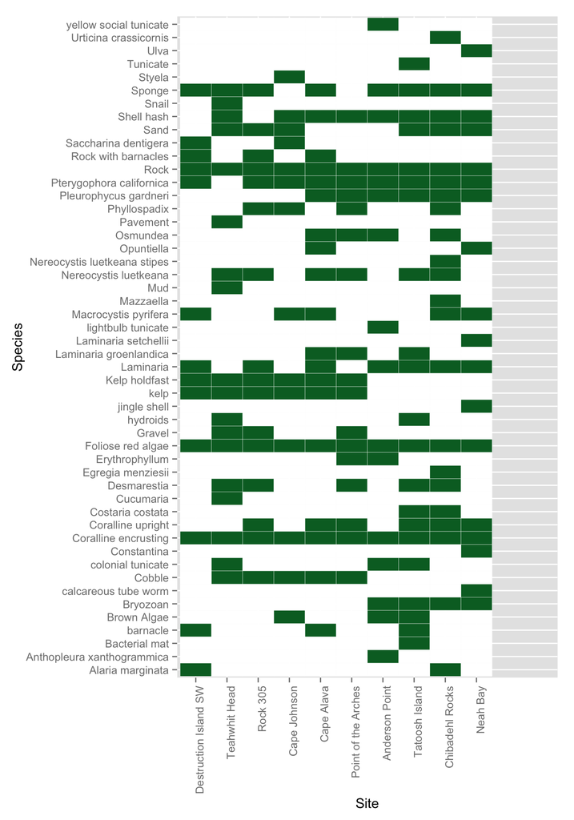

### Fish species on transects

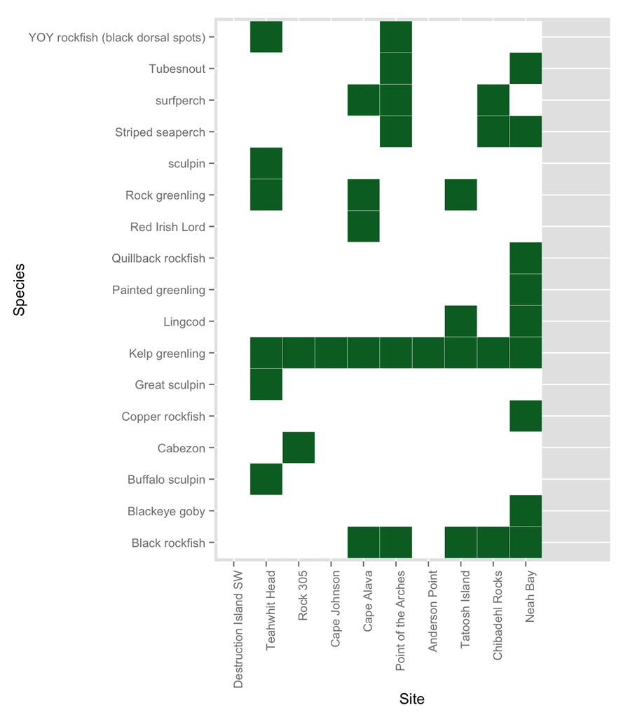

### Mobile invertebrate species on transects

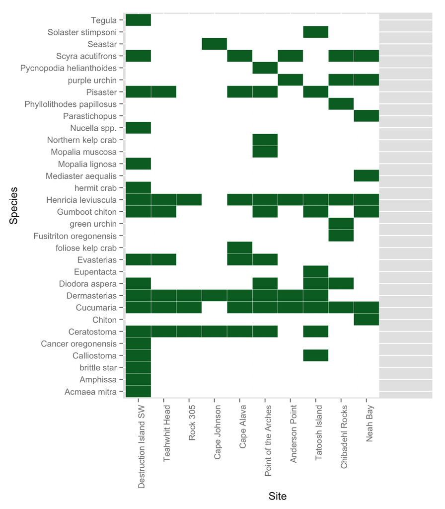

\newpage

## Comparing mobile invertebrates

Data from all sites in all years. I include only data from 6m and shallower from historical data.

### Urchins (Mean +/- SD).

Zeros shown as thin lines, missing data shown as blank

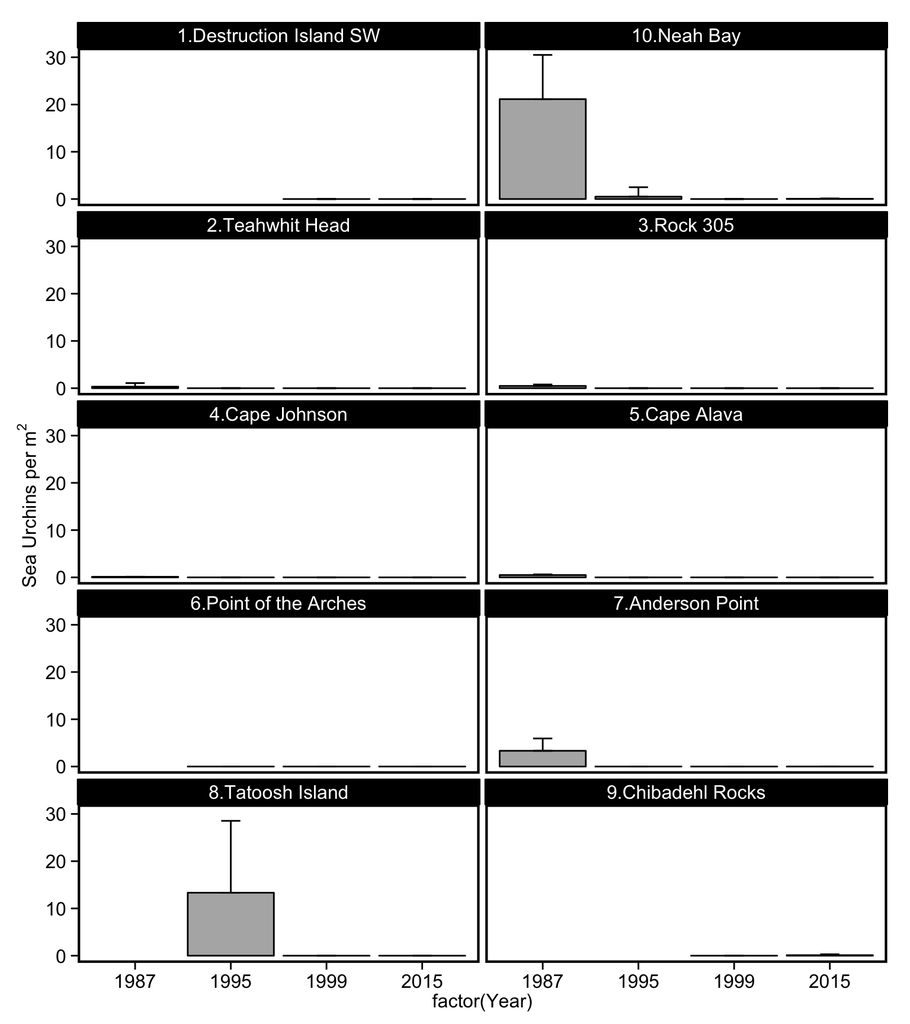

\newpage

### Sea Cucumbers (Mean +/- SD).

Zeros shown as thin lines, missing data shown as blank

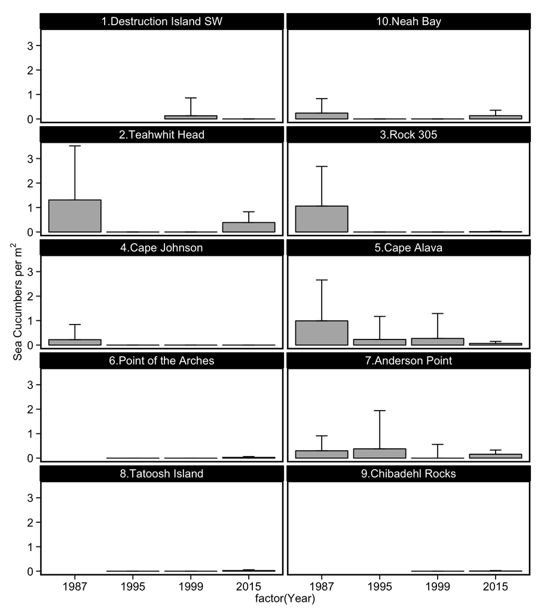

\newpage

### Scallops (Mean +/- SD).

Zeros shown as thin lines, missing data shown as blank

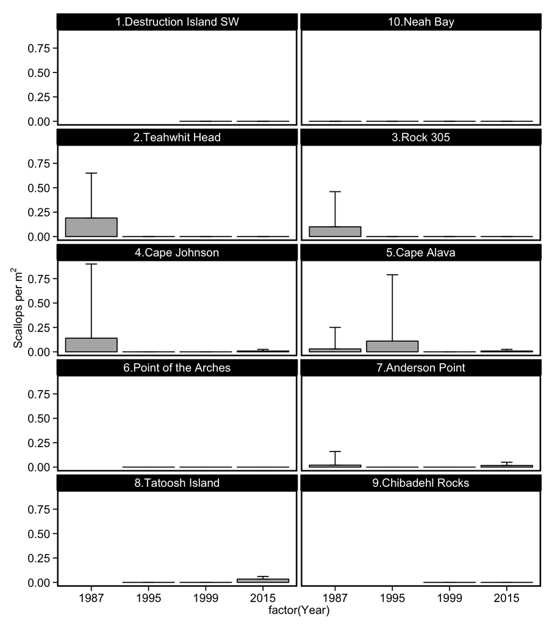

\newpage

### Crabs (Mean +/- SD).

Zeros shown as thin lines, missing data shown as blank

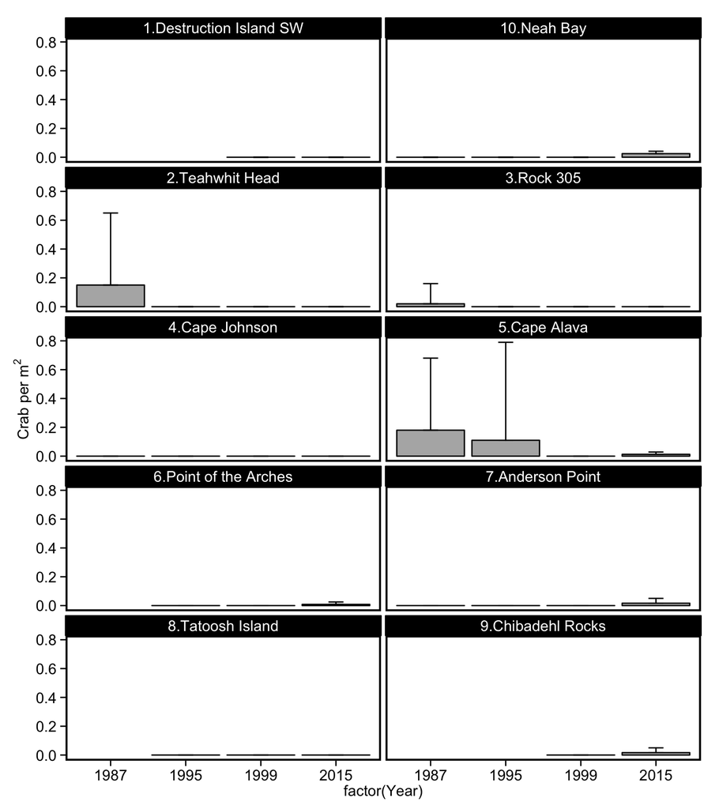

\newpage

### Limpets (Mean +/- SD).

Zeros shown as thin lines, missing data shown as blank

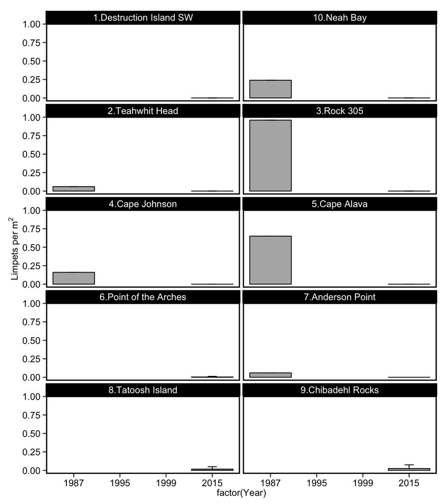

\newpage

### Non-Limpet Gastropods (Mean +/- SD).

Zeros shown as thin lines, missing data shown as blank

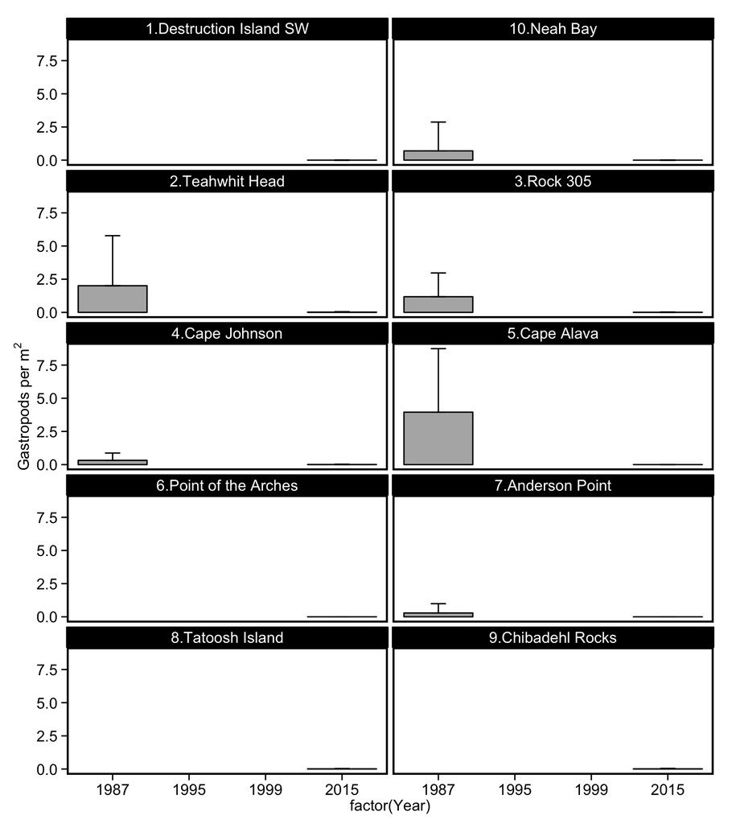